# Principle Component Analysis & Clustering for Gene_Expression

This is for analyzing the PCA of gene expression data.

```r
library(pls)
```

```r
library(ggplot2)
```

```r
library(dplyr)
```

```r
gene_exp <- readRDS('data/gene_expression.rds')
```

## PCA

Using `prcomp` is an easier way than the one we have learnt in the meeting to do PCA(learnt from the ISL book). When I do PCA, the `prcomp` function by default centers the data but not necessarily scales the data. I have to try both to see which one performs better.

```r
pr.out <- prcomp(gene_exp)
```

```r
names(pr.out)
```

1. 'sdev'

2. 'rotation'

3. 'center'

4. 'scale'

5. 'x'

We first decide how many principle components we need to include based on how much standard deviation is explained.

```r
pr.var = pr.out$sdev^2
pr.var[1:5]
```

1. 1473.91576925006

2. 872.15168441029

3. 686.754359333693

4. 312.076083968845

5. 238.727807152541

I take a look at how much variance is explained.

```r
pve = pr.var/sum(pr.var)
pve[1:5]
```

1. 0.123304686459901

2. 0.0729623715515325

3. 0.0574524221256533

4. 0.0261076273747932

5. 0.0199714651436162

```r
sum(pve[1:5])
```

0.299798572655497

I try again with scaled variables. The result is not as satisfactory. Therefore I am going to pick the previous PCA w/o scaling.

```r
pr_scale.out <- prcomp(gene_exp,scale=TRUE)
```

```r
pr_scale.var = pr_scale.out$sdev^2
pr_scale.var[1:5]
```

1. 1404.63190002725

2. 756.459886329526

3. 589.418193110853

4. 475.210724294468

5. 372.305648959507

```r
pve_scale = pr_scale.var/sum(pr_scale.var)
pve_scale[1:5]
```

1. 0.0791921914657072

2. 0.0426486940480085

3. 0.0332309969617665

4. 0.0267920575235084

5. 0.0209903393448445

```r
sum(pve_scale[1:10])
```

0.273462442062307

## Clustering

```r
matdist = pr.out$x[,1:3]
```

```r
matdist[1:6,1:3]
```

|  | PC1 | PC2 | PC3 |
| --- | --- | --- | --- |
| 683665 | 70.37903 | -24.66007 | 48.328322 |
| 683667 | 12.23339 | 32.81363 | -3.268764 |
| 684052 | 24.58613 | 32.55236 | -19.908916 |
| 684055 | 33.11499 | 38.57256 | -29.384040 |
| 684057 | 32.92997 | 29.54026 | -28.632242 |
| 684059 | 15.56819 | 39.05821 | -14.950088 |

Clustering with complete linkage.

```r
hc.complete = hclust(dist(matdist),method="complete")
```

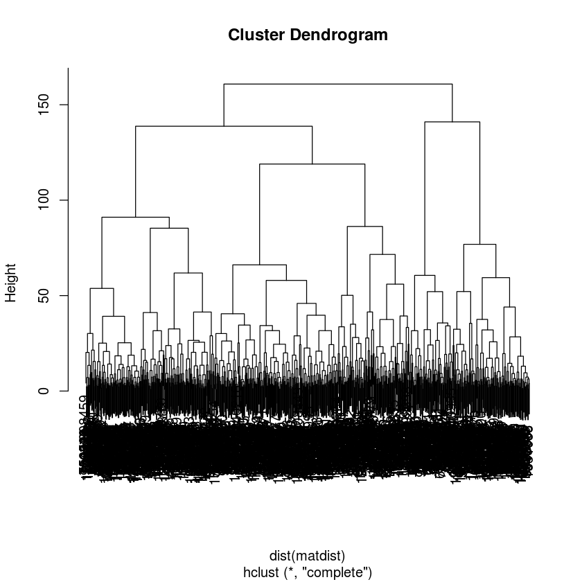

```r
plot(hc.complete)
```

Clustering with Ward method.

```r
hc.ward = hclust(dist(matdist),method="ward.D")
```

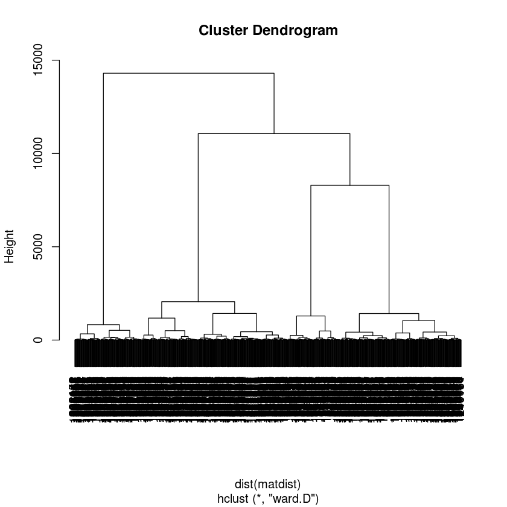

```r
plot(hc.ward)
```

Clustering with average linkage.

```r
hc.average = hclust(dist(matdist),method = "average")
```

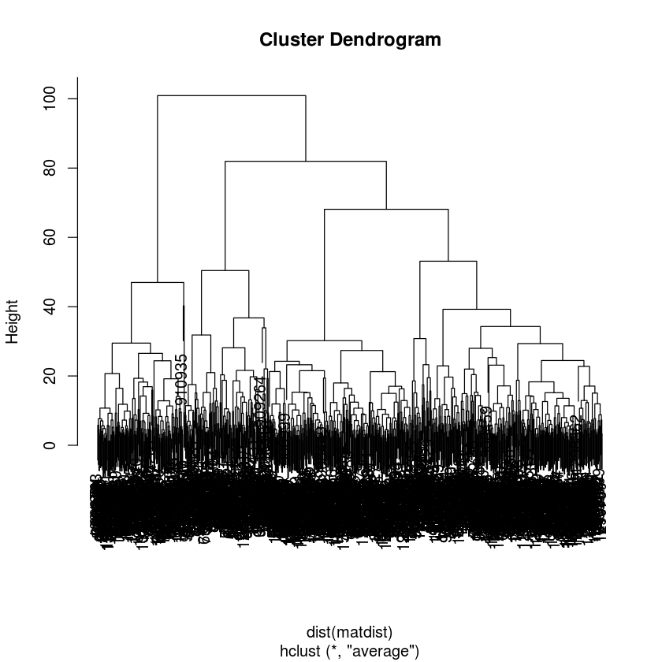

```r
plot(hc.average)
```

Clustering with single linkage. Doesn't seem to work well.

```r
hc.single = hclust(dist(matdist),method="single")
```

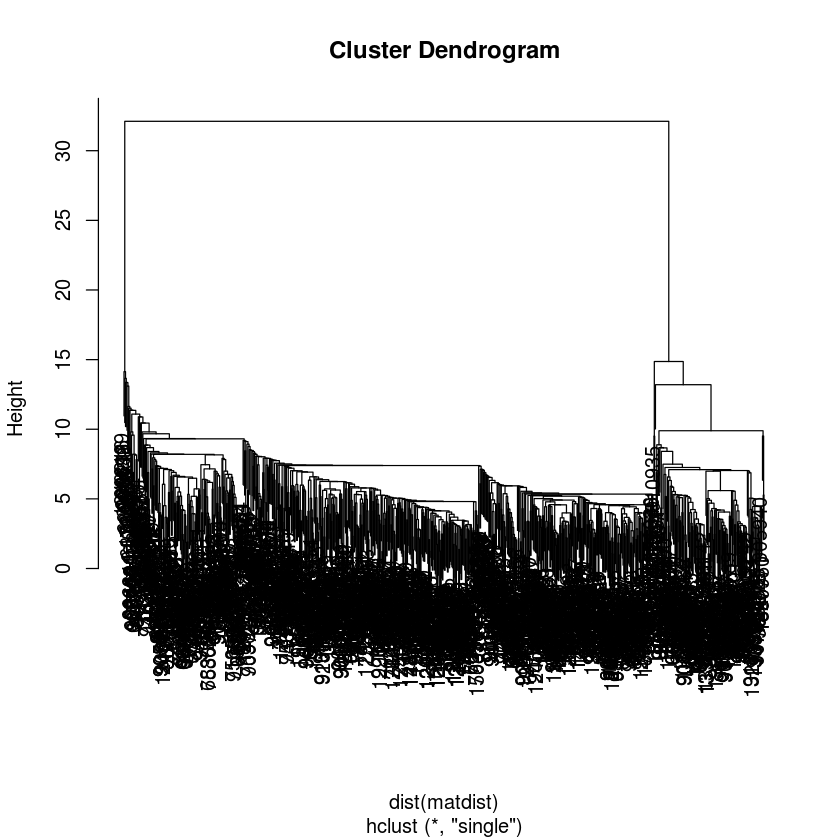

```r
plot(hc.single)
```